# More linear regression

In this tutorial, we will practice interpreting the output of different types of linear regression. Again, we will use the same XBOT dataset as in previous tutorials.

```r
df <- read.csv("crisp-2024-sample100.csv")
```

We will also learn how to graph linear regression lines using `ggplot2`.

## Binary predictor

Suppose that we are examining number of years of education (`educyrs`) as our outcome, and binarized sex (`sex`) as our single predictor.

Note that `sex` takes the value of 0 or 1 in our dataset, with 0 representing males and 1 representing females.

Our data looks like the following:

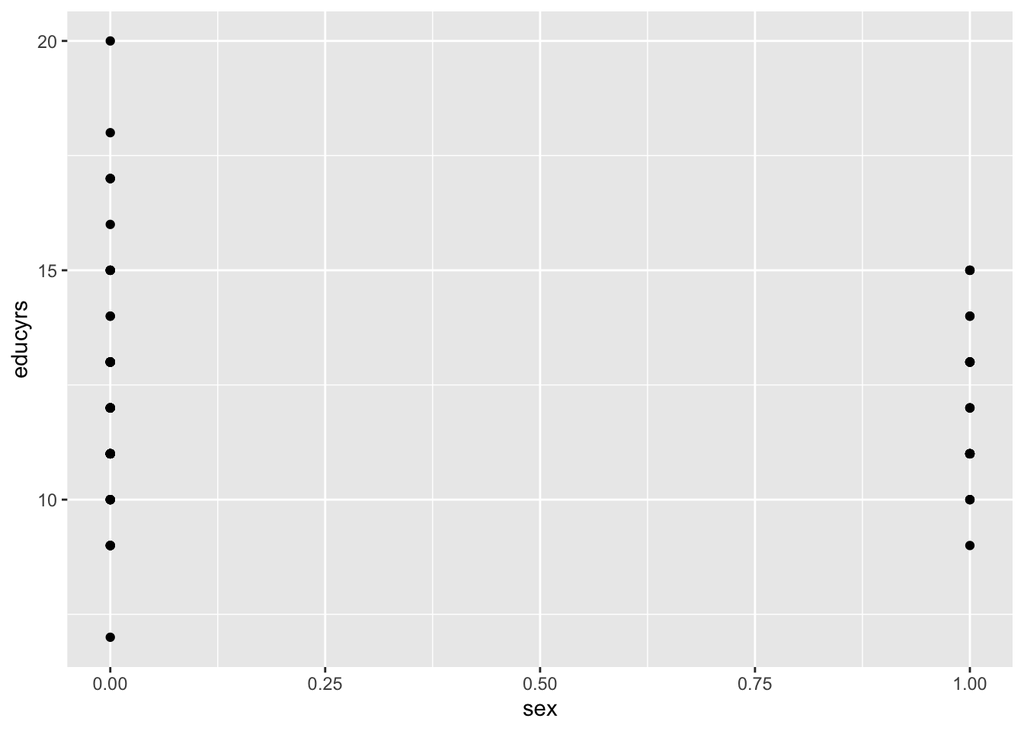

```r
library(ggplot2)

ggplot(data = df, aes(x = sex, y = educyrs)) +
  geom_point()
```

We aim to find the best linear fit considering these data points. That is, we aim to fit the model:

$$educyrs = \beta_0 + \beta_1 sex$$

We perform a linear regression, regressing `educyrs` on `sex` using the `lm()` function.

```r
mod1 <- lm(educyrs ~ sex, data = df)

summary(mod1)
```

```
##
## Call:
## lm(formula = educyrs ~ sex, data = df)
##
## Residuals:
##     Min      1Q  Median      3Q     Max
## -5.2113 -1.2113 -0.2113  0.8276  7.7887
##
## Coefficients:
##             Estimate Std. Error t value Pr(>|t|)
## (Intercept) 12.21127    0.25203  48.451   <2e-16 ***
## sex         -0.03885    0.46801  -0.083    0.934
## ---
## Signif. codes:  0 '***' 0.001 '**' 0.01 '*' 0.05 '.' 0.1 ' ' 1
##
## Residual standard error: 2.124 on 98 degrees of freedom
## Multiple R-squared:  7.032e-05,  Adjusted R-squared:  -0.01013
## F-statistic: 0.006892 on 1 and 98 DF,  p-value: 0.934
```

How can we interpret this output?

- *Intercept*: The mean number of years of education for males (or those with sex = 0). That is, males have on average 12.21 years of education.
- *Coefficient on sex*: The difference in the mean number of years of education between females and males. That is, we estimate that females have on average 0.039 fewer years of education than males.
  - *p-value*: The result from testing the null hypothesis that the coefficient on sex is equal to 0. Equivalently, we are testing the null hypothesis that there is no difference in number of years of education between males and females. With $p = 0.93$, we fail to find evidence of a difference in the number of years of education comparing males and females.

We can also obtain confidence intervals on these estimates using `confint()`.

```r
confint(mod1)
```

```
##                  2.5 %     97.5 %
## (Intercept) 11.7111206 12.7114146
## sex         -0.9676034  0.8898958
```

We can look at what this line looks like on top of the data. To do this, we add a smoothed linear regression line using `+ geom_smooth(method = "lm")`.

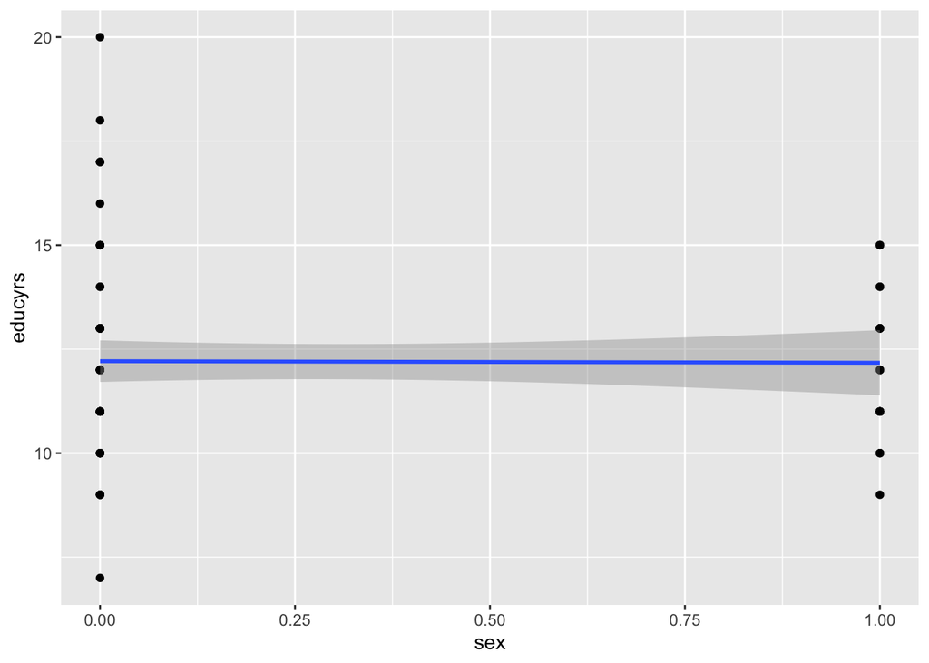

```r
ggplot(data = df, aes(x = sex, y = educyrs)) +
  geom_point() +
  geom_smooth(method = "lm")
```

## Continuous predictor

Suppose that we are examining BMI (`bmi`) as our outcome and number of years of education (`educyrs`) as our single predictor. Note that both variables here are continuous.

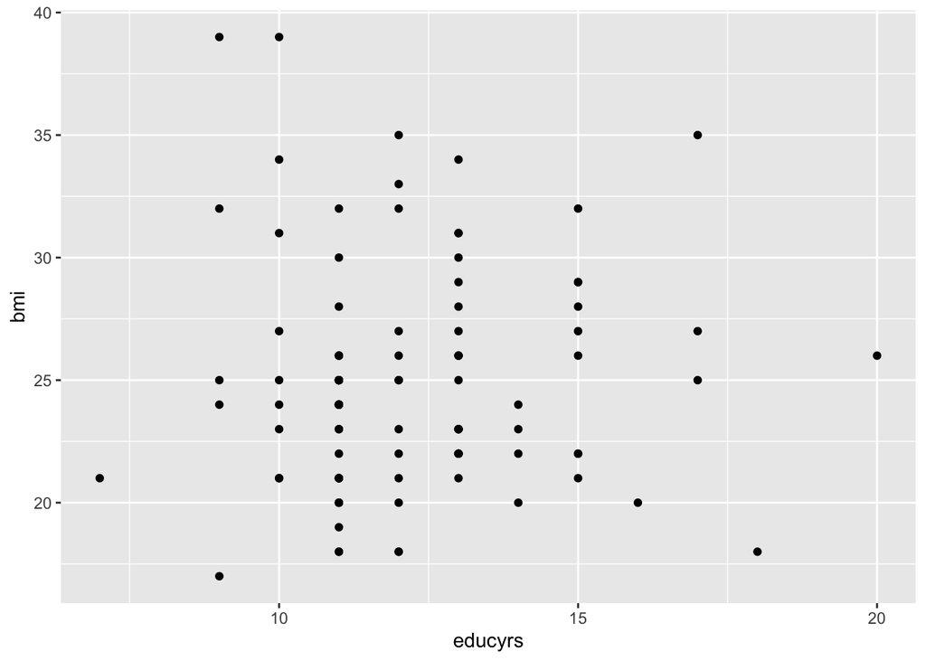

```r
ggplot(data = df, aes(x = educyrs, y = bmi)) +
  geom_point()
```

We are trying to find a best fit line to fit this data. That is, we are trying find the best estimates of $\beta_0$ and $\beta_1$ in the equation below:

$$bmi = \beta_0 + \beta_1 educyrs$$

We perform a linear regression, regressing `bmi` on `educyrs` using the `lm()` function.

```r
mod2 <- lm(bmi ~ educyrs, data = df)

summary(mod2)
```

```
##
## Call:
## lm(formula = bmi ~ educyrs, data = df)
##
## Residuals:
##     Min      1Q  Median      3Q     Max
## -7.8132 -3.0944 -0.8376  1.9667 14.1868
##
## Coefficients:
##             Estimate Std. Error t value Pr(>|t|)
## (Intercept)  24.3731     2.7265   8.939 2.82e-14 ***
## educyrs       0.0489     0.2203   0.222    0.825
## ---
## Signif. codes:  0 '***' 0.001 '**' 0.01 '*' 0.05 '.' 0.1 ' ' 1
##
## Residual standard error: 4.628 on 96 degrees of freedom
##   (2 observations deleted due to missingness)
## Multiple R-squared:  0.0005131,  Adjusted R-squared:  -0.009898
## F-statistic: 0.04928 on 1 and 96 DF,  p-value: 0.8248
```

We can again obtain confidence intervals and graph the best fit line on top of the data:

```r
confint(mod2)
```

```
##                  2.5 %     97.5 %
## (Intercept) 18.9610051 29.7851393
## educyrs     -0.3883599  0.4861656
```

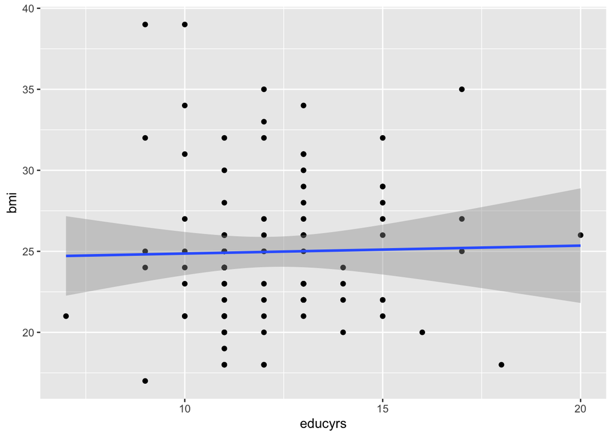

```r
ggplot(data = df, aes(x = educyrs, y = bmi)) +
  geom_point() +
  geom_smooth(method = "lm")
```

## Binary and continuous predictors

Suppose that we run a linear regression, with number of years of education `educyrs` as the outcome, and `age` and `sex` as the predictors. That is, we are trying find the best estimates of $\beta_0$, $\beta_1$, and $\beta_2$ in the equation below:

$$educyrs = \beta_0 + \beta_1 age + \beta_2 sex$$

To do this in R, we can use `lm()` with `age + sex` as our predictors in the formula:

```r
mod3 <- lm(educyrs ~ age + sex, data = df)

summary(mod3)
```

```
##
## Call:
## lm(formula = educyrs ~ age + sex, data = df)
##
## Residuals:
##     Min      1Q  Median      3Q     Max
## -4.5083 -1.3428 -0.4806  1.0569  7.5194
##
## Coefficients:
##             Estimate Std. Error t value Pr(>|t|)
## (Intercept) 14.36048    0.79808  17.994  < 2e-16 ***
## age         -0.06482    0.02292  -2.828  0.00569 **
## sex         -0.14054    0.45358  -0.310  0.75733
## ---
## Signif. codes:  0 '***' 0.001 '**' 0.01 '*' 0.05 '.' 0.1 ' ' 1
##
## Residual standard error: 2.052 on 97 degrees of freedom
## Multiple R-squared:  0.07622,    Adjusted R-squared:  0.05718
## F-statistic: 4.002 on 2 and 97 DF,  p-value: 0.02138
```

How can we interpret the output?

- *Intercept*: The predicted number of years of education for males (sex = 0) with age = 0. Note that this is not meaningful, since we don’t have age = 0 in our population of interest.
- *Coefficient on age*: The estimated difference in number of years of education comparing two groups *of the same sex* differing by one year of age.
- *Coefficient on sex*: The estimated difference in the number of years of education comparing females versus males *of the same age*.

*[Click here](https://jpspeng.github.io/crisp_notes/) to go back to the CRISP R notes homepage.*